# Lab 6 - Analyzing Different Feature Selection Techniques

Cameron Wonchoba

03/01/2020

# Overview

### Background

In this lab, we are given a dataset that describes a customer and their product usage. The goal of of this data-set is to predict whether a customer would be interested in buying a caravan insurance policy. Further, an explanation as to why they would be interested is useful.

### Problem

This is binary classification problem, where we are trying to predict whether a certain customer owns Caravan insurance (represent as 1) or not (represented as 0).

### Methods

We will be making predictions using the following techniques:

1. Logistic regression with all features (base model)
2. Logistic regression with stepwise selection based on p-values
3. Random Forest based on Principal component analysis feature selection
4. Random Forest based on feature importance feature selection

Model performance will be tracked for each model.

# Data

The data can be found on kaggle [here](https://www.kaggle.com/uciml/caravan-insurance-challenge/home). The data consists of 86 variables and includes product usage data and socio-demographic data derived from zip area codes.

Using this data, we must predict whether a consumer is interested in buying Caravan insurance and why.

> Note: To get the data, select the link above (here), and select Download in the top right hand corner. If you don't have a Kaggle account, you must create one.

```python
import pandas as pd
pd.set_option('display.max_columns', None) # Display all columns.
from pandas_profiling import ProfileReport

#Note you may need to install pandas_profiling - Run anaconda prompt as admin and run:
#'conda install -c conda-forge pandas-profiling'
```

```python
df = pd.read_csv('caravan-insurance-challenge.csv')
df.head()
```

|  | ORIGIN | MOSTYPE | MAANTHUI | MGEMOMV | MGEMLEEF | MOSHOOFD | MGODRK | MGODPR | MGODOV | MGODGE | MRELGE | MRELSA | MRELOV | MFALLEEN | MFGEKIND | MFWEKIND | MOPLHOOG | MOPLMIDD | MOPLLAAG | MBERHOOG | MBERZELF | MBERBOER | MBERMIDD | MBERARBG | MBERARBO | MSKA | MSKB1 | MSKB2 | MSKC | … |
| --- | --- | --- | --- | --- | --- | --- | --- | --- | --- | --- | --- | --- | --- | --- | --- | --- | --- | --- | --- | --- | --- | --- | --- | --- | --- | --- | --- | --- | --- | --- |
| 0 | train | 33 | 1 | 3 | 2 | 8 | 0 | 5 | 1 | 3 | 7 | 0 | 2 | 1 | 2 | 6 | 1 | 2 | 7 | 1 | 0 | 1 | 2 | 5 | 2 | 1 | 1 | 2 | 6 | … |
| 1 | train | 37 | 1 | 2 | 2 | 8 | 1 | 4 | 1 | 4 | 6 | 2 | 2 | 0 | 4 | 5 | 0 | 5 | 4 | 0 | 0 | 0 | 5 | 0 | 4 | 0 | 2 | 3 | 5 | … |
| 2 | train | 37 | 1 | 2 | 2 | 8 | 0 | 4 | 2 | 4 | 3 | 2 | 4 | 4 | 4 | 2 | 0 | 5 | 4 | 0 | 0 | 0 | 7 | 0 | 2 | 0 | 5 | 0 | 4 | … |
| 3 | train | 9 | 1 | 3 | 3 | 3 | 2 | 3 | 2 | 4 | 5 | 2 | 2 | 2 | 3 | 4 | 3 | 4 | 2 | 4 | 0 | 0 | 3 | 1 | 2 | 3 | 2 | 1 | 4 | … |
| 4 | train | 40 | 1 | 4 | 2 | 10 | 1 | 4 | 1 | 4 | 7 | 1 | 2 | 2 | 4 | 4 | 5 | 4 | 0 | 0 | 5 | 4 | 0 | 0 | 0 | 9 | 0 | 0 | 0 | … |

# Exploratory Data Analysis

Using Pandas Profiler, a report will be generated. Using this report we can easily investigate each variable, multiple correlations matricies and a sample of the data.

```python
#Generating Profile Report
profile = ProfileReport(df)

#Outputing Profile Report to html file in current directory
profile
```

Report generated with pandas-profiling.

### Things to note:

- There are 9822 distinct observations.
- According to the documenation, the ORIGIN column should be used as our train test splits. This is not a value we should be training on.
- The target variable is Caravan.
  - This variable is exteremely imbalanced 586 positive obeservations, 9236 negative observations). Sampling techniques may be useful here.
- Looking at the Peason Correlation Matrix, there are several variables that are highly correlated with each other. Feature selection will help us out here.
- Data is not missing any values.
- There are various data types:
  - NUM 68
  - CAT 13
  - BOOL 6

# Techniques/Models

Four different models/technique combinations will be trained and tested.

1. Logistic regression with all features (base model)
2. Logistic regression with stepwise selection based on p-values
3. Random Forest based on Principal component analysis feature selection
4. Random Forest based on feature importance feature selection

For each combination, we will be training a model on a pre-determined testing set (defined by the ORIGIN column), and testing the model on the testing set.

```python
# Split into train and test.
train = df[df['ORIGIN'] == 'train']
test = df[df['ORIGIN'] == 'test']

# Drop ORIGIN column
train = train.drop(['ORIGIN'], axis=1)
test = test.drop(['ORIGIN'], axis=1)

# Split into features and target.
X_train = train.loc[:, train.columns != 'CARAVAN']
y_train = train.loc[:, train.columns == 'CARAVAN']

X_test = test.loc[:, test.columns != 'CARAVAN']
y_test = test.loc[:, test.columns == 'CARAVAN']
```

```python
# Import models and feature selection techniques.
from sklearn.linear_model import LogisticRegression
from sklearn.ensemble import RandomForestClassifier
import matplotlib.pyplot as plt
import numpy as np

# Import metrics
from sklearn.metrics import accuracy_score
from sklearn.metrics import roc_curve
from sklearn.metrics import precision_recall_curve
from sklearn.metrics import plot_precision_recall_curve
from sklearn.metrics import average_precision_score
from sklearn.metrics import auc
from sklearn.metrics import confusion_matrix
```

```python
def test_model(model_choice, X_train, y_train, X_test, y_test, model_name):
    """Trains model, and evaluates it."""
    # Train model.
    model = model_choice()
    model.fit(X_train, y_train)

    # Make predictions on testing data.
    preds = model.predict(X_test)
    preds_prob = model.predict_proba(X_test)[:,1]

    # Calculate metrics (roc_auc, accuracy, precision, recall, f1)

    # ROC_AUC
    fpr, tpr, thresholds = roc_curve(y_test, preds_prob)
    roc_auc = auc(fpr, tpr)

    # ACCURACY
    acc = accuracy_score(y_test, preds)

    # PRECISION/RECALL
    tn, fp, fn, tp = confusion_matrix(y_test, preds).ravel()
    precision = tp/(tp+fp)
    recall = tp/(tp+fn)

    # F1
    f1 = (1 + 1) * (precision*recall)/(1*precision+recall)

    print(f"\n Model: {model_name}\n\troc_auc: {roc_auc}\n\tAccuracy: {acc}\n\tPrecision: {precision}\n\tRecall:{recall}\n\tF1:{f1}")
    print("Confusion Matrix:")
    print("--------------------")
    print("tp: ", tp,"|","fn: ", fn)
    print("--------------------")
    print("fp: ", fp,"|","tn: ", tn)
    print("--------------------\n")

    # Create plot.
    label='AUC = %0.2f' % (roc_auc)
    plt.plot([0, 1], [0, 1], 'k--')
    plt.plot(fpr, tpr, label=label, color=np.random.rand(3))

    # Show plot.
    plt.xlabel('False Positive Rate')
    plt.ylabel('True Positive Rate')
    plt.title(f'{model_name} ROC Curve')
    plt.legend(loc="lower right")
    plt.show()
```

### Logistic regression with all features (base model)

```
 Model: LogisticRegression
	roc_auc: 0.7265378240610438
	Accuracy: 0.94075
	Precision: 0.6
	Recall:0.012605042016806723
	F1:0.02469135802469136
Confusion Matrix:
--------------------
tp:  3 | fn:  235
--------------------
fp:  2 | tn:  3760
--------------------
```

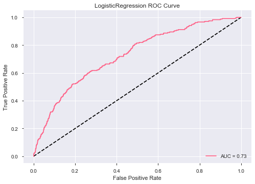

```python
test_model(LogisticRegression, X_train, y_train, X_test, y_test, "LogisticRegression")
```

We get a 94% accuracy, which seems really good. However, we have really imbalanced classes, so even if we predict all negatives (0), we will still get ~ 94% accuracy.

Looking at the confusion matrix, that is exactly what this model did. It predicted all but 5 samples as negative (not owning CARAVAN).

This means that we should reject this model and explore other methods.

### Logistic regression with stepwise selection based on p-values

```python
import statsmodels.api as sm
```

```python
def stepwise_selection(X, y,
                       initial_list=[],
                       threshold_in=0.01,
                       threshold_out = 0.05,
                       verbose=True):
    """ Perform a forward-backward feature selection
    based on p-value from statsmodels.api.OLS
    Arguments:
        X - pandas.DataFrame with candidate features
        y - list-like with the target
        initial_list - list of features to start with (column names of X)
        threshold_in - include a feature if its p-value < threshold_in
        threshold_out - exclude a feature if its p-value > threshold_out
        verbose - whether to print the sequence of inclusions and exclusions
    Returns: list of selected features
    Always set threshold_in < threshold_out to avoid infinite looping.
    See https://en.wikipedia.org/wiki/Stepwise_regression for the details
    """
    included = list(initial_list)
    while True:
        changed=False
        # forward step
        excluded = list(set(X.columns)-set(included))
        new_pval = pd.Series(index=excluded)
        for new_column in excluded:
            model = sm.OLS(y, sm.add_constant(pd.DataFrame(X[included+[new_column]]))).fit()
            new_pval[new_column] = model.pvalues[new_column]
        best_pval = new_pval.min()
        if best_pval < threshold_in:
#            best_feature = new_pval.argmin()
            best_feature = new_pval.idxmin()
            included.append(best_feature)
            changed=True
            if verbose:
                print('Add  {:30} with p-value {:.6}'.format(best_feature, best_pval))

        # backward step
        model = sm.OLS(y, sm.add_constant(pd.DataFrame(X[included]))).fit()
        # use all coefs except intercept
        pvalues = model.pvalues.iloc[1:]
        worst_pval = pvalues.max() # null if pvalues is empty
        if worst_pval > threshold_out:
            changed=True
            worst_feature = pvalues.argmax()
            included.remove(worst_feature)
            if verbose:
                print('Drop {:30} with p-value {:.6}'.format(worst_feature, worst_pval))
        if not changed:
            break
    return included

result = stepwise_selection(X_train, y_train)

print('resulting features:')
print(result)
```

```
Add  PPERSAUT                       with p-value 5.28958e-31
Add  APLEZIER                       with p-value 5.67554e-15
Add  MKOOPKLA                       with p-value 1.8286e-12
Add  PWAPART                        with p-value 8.03918e-09
Add  MOPLLAAG                       with p-value 9.84051e-05
Add  MRELGE                         with p-value 0.000261024
Add  PBRAND                         with p-value 0.00113092
Add  ABYSTAND                       with p-value 0.00153451
Add  MBERBOER                       with p-value 0.00340782
Add  AFIETS                         with p-value 0.00620814
resulting features:
['PPERSAUT', 'APLEZIER', 'MKOOPKLA', 'PWAPART', 'MOPLLAAG', 'MRELGE', 'PBRAND', 'ABYSTAND', 'MBERBOER', 'AFIETS']
```

```
 Model: LogisticRegression
	roc_auc: 0.7168433561622416
	Accuracy: 0.94025
	Precision: 0.4
	Recall:0.008403361344537815
	F1:0.016460905349794237
Confusion Matrix:
--------------------
tp:  2 | fn:  236
--------------------
fp:  3 | tn:  3759
--------------------
```

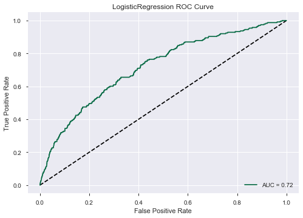

```python
X_train_sub = X_train[result]
X_test_sub = X_test[result]

test_model(LogisticRegression, X_train_sub, y_train, X_test_sub, y_test, "LogisticRegression")
```

The results are extremely similar to our baseline model (Logistic Regression with all features). This model performs slightly worse in identifying True Positives (only find two instances correctly).

We would want to reject this model and try something else.

### Random Forest based on Principal component analysis feature selection

```python
from sklearn.model_selection import train_test_split
from sklearn.decomposition import PCA
from sklearn.preprocessing import StandardScaler
from sklearn.ensemble import RandomForestClassifier
```

```python
# First scaled standardize the data.

X_train_std = StandardScaler().fit_transform(X_train)
X_test_std = StandardScaler().fit_transform(X_test)
```

```python
X_train_pca = PCA(n_components=6).fit_transform(X_train_std)
X_test_pca = PCA(n_components=6).fit_transform(X_test_std)

assert X_train_pca.shape[1] == X_test_pca.shape[1], "[ERROR] - There should be the same number of Principal Components"
```

```
 Model: RandomForestClassifier
	roc_auc: 0.6500894616219693
	Accuracy: 0.94025
	Precision: 0.0
	Recall:0.0
	F1:nan
Confusion Matrix:
--------------------
tp:  0 | fn:  238
--------------------
fp:  1 | tn:  3761
--------------------
```

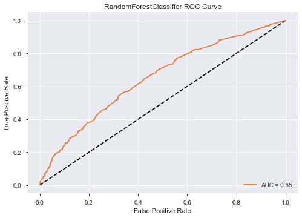

```python
test_model(RandomForestClassifier, X_train_pca, y_train, X_test_pca, y_test, "RandomForestClassifier")
```

Using PCA, we are seeing worse results. In fact, we didn't identify the positive class once. This makes senses as we are utilizing less of the total explained variance.

We should reject this model and move onto to something else.

### Random Forest based on feature importance feature selection

This will be built using the following steps:

1. Build model with all features.
2. Extract "important" features.
3. Build new model with important features.
4. Evaluate.

References: https://scikit-learn.org/stable/auto_examples/ensemble/plot_forest_importances.html

```
Feature ranking:
1. feature 58 (0.054771)
2. feature 67 (0.043854)
3. feature 46 (0.042919)
4. feature 0 (0.037984)
5. feature 43 (0.028586)
6. feature 42 (0.023384)
7. feature 4 (0.021366)
8. feature 64 (0.021043)
9. feature 21 (0.020870)
10. feature 79 (0.020384)
11. feature 27 (0.019271)
12. feature 14 (0.019056)
13. feature 13 (0.018732)
14. feature 15 (0.018572)
15. feature 17 (0.018133)
16. feature 8 (0.018123)
17. feature 6 (0.017540)
18. feature 37 (0.017297)
19. feature 16 (0.016701)
20. feature 22 (0.016649)
21. feature 38 (0.016628)
22. feature 30 (0.016214)
23. feature 23 (0.015989)
24. feature 18 (0.015363)
25. feature 25 (0.015324)
26. feature 34 (0.015308)
27. feature 29 (0.015255)
28. feature 35 (0.014898)
29. feature 12 (0.014831)
30. feature 36 (0.014779)
31. feature 9 (0.014683)
32. feature 39 (0.014665)
33. feature 24 (0.014480)
34. feature 26 (0.014098)
35. feature 31 (0.013785)
36. feature 75 (0.013615)
37. feature 7 (0.013164)
38. feature 41 (0.012624)
39. feature 54 (0.012044)
```

[output cut: 31 more lines]

```
71. feature 65 (0.002299)
72. feature 83 (0.001886)
73. feature 72 (0.001884)
74. feature 47 (0.001565)
75. feature 68 (0.001196)
76. feature 66 (0.000806)
77. feature 45 (0.000664)
78. feature 80 (0.000587)
79. feature 59 (0.000391)
80. feature 76 (0.000378)
81. feature 55 (0.000370)
82. feature 73 (0.000057)
83. feature 52 (0.000057)
84. feature 70 (0.000001)
85. feature 49 (0.000000)
```

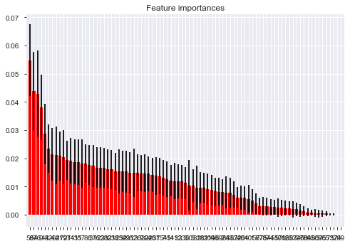

```python
model = RandomForestClassifier()
model.fit(X_train, y_train)

importances = model.feature_importances_
std = np.std([tree.feature_importances_ for tree in model.estimators_],
             axis=0)

indices = np.argsort(importances)[::-1]

# Print the feature ranking
print("Feature ranking:")

for f in range(X_train.shape[1]):
    print("%d. feature %d (%f)" % (f + 1, indices[f], importances[indices[f]]))

# Plot the feature importances of the forest
plt.figure()
plt.title("Feature importances")
plt.bar(range(X_train.shape[1]), importances[indices],
       color="r", yerr=std[indices], align="center")
plt.xticks(range(X_train.shape[1]), indices)
plt.xlim([-1, X_train.shape[1]])
plt.show()
```

```python
# Grab the 10 most important features

X_train_feat = X_train.iloc[:,indices[:10]]
X_test_feat = X_test.iloc[:,indices[:10]]

X_train_feat.columns
```

```
Index(['PBRAND', 'APERSAUT', 'PPERSAUT', 'MOSTYPE', 'PWAPART', 'MKOOPKLA',
       'MOSHOOFD', 'AWAPART', 'MBERMIDD', 'ABRAND'],
      dtype='object')
```

```
 Model: RandomForestClassifier
	roc_auc: 0.6462920894035444
	Accuracy: 0.92775
	Precision: 0.16883116883116883
	Recall:0.0546218487394958
	F1:0.08253968253968254
Confusion Matrix:
--------------------
tp:  13 | fn:  225
--------------------
fp:  64 | tn:  3698
--------------------
```

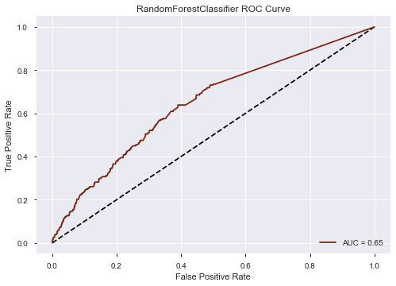

```python
test_model(RandomForestClassifier, X_train_feat, y_train, X_test_feat, y_test, "RandomForestClassifier")
```

Using the top 10 features, we were able to get a similar accuracy, similar ROC_AUC, and a better f1 score than the Random Forest that uses PCA.

One benefit that we get from this is model explainability. We are able to effectively communicate to any stakeholders why someone may or may not be likely to buy CARAVAN insurance.

# Conclusions

We are able to get a 94% accuracy by just identifying every new case as not likely to buy CARAVAN insurance (labeled as 0). This is because our classes are imbalanced.

We use the f1 score and roc_auc to evaluate our models because of this imbalance.

### Logistic Regression (Base Model)

Model: LogisticRegression

```
roc_auc: 0.7265378240610438
Accuracy: 0.94075
Precision: 0.6
Recall:0.012605042016806723
F1:0.02469135802469136
```

### Logistic Regression Using Stepwise Feature Selection

Model: LogisticRegression

```
roc_auc: 0.7168433561622416
Accuracy: 0.94025
Precision: 0.4
Recall:0.008403361344537815
F1:0.016460905349794237
```

### Random Forest Using PCA

Model: RandomForestClassifier

```
roc_auc: 0.6500894616219693
Accuracy: 0.94025
Precision: 0.0
Recall:0.0
F1:nan
```

### Random Forest Using Feature Importance

Model: RandomForestClassifier

[output not shown]

When evaluating the roc_auc score, our **base model** performs the best (not removing any features). However, we are more interested in the **f1** score. We are interested in this because it tells us how much we are able to identify True Positives. All of our models have really bad f1 scores, but using **Random Forest with Feature Importance** performed the best.

### Recommendation

My recommendation would be to reject all of these models and implement some sort of resampling and feature engineering to see if we can get better results.